# US Youtube Videos - Data Visualization

Tubagus Fathul Arifin

2022-08-01

[figure not shown]

# **1. DATA INTRODUCTION**

As a *“YouTuber”* in America who wants to increase the prestige of his YouTube channel, we plan to create trending video content! We just got data on *“YouTube’s US Trending Videos”* and want to find out **what characteristics make a video trending**?

*“YouTube US Trending Videos”* is a collection of 200 trending videos in the US per day from 2017-11-14 to 2018-01-21.

# **2. DATA PREPARATION**

Input the data and store it in a variable named **Videos**

```r
Videos <- read.csv("data_input/USvideos.csv")
```

And now we can do data inspection and cleansing`

## **2.1. Data Inspection**

Check if the saved data is correct

```r
head(Videos)
```

|  | trending_date | title | channel_title | category_id | publish_time | views | likes | dislikes | comment_count | comments_disabled | ratings_disabled | video_error_or_removed |
| --- | --- | --- | --- | --- | --- | --- | --- | --- | --- | --- | --- | --- |
| 1 | 17.14.11 | WE WANT TO TALK ABOUT OUR MARRIAGE | CaseyNeistat | 22 | 2017-11-13T17:13:01.000Z | 748374 | 57527 | 2966 | 15954 | FALSE | FALSE | FALSE |
| 2 | 17.14.11 | The Trump Presidency: Last Week Tonight with John Oliver (HBO) | LastWeekTonight | 24 | 2017-11-13T07:30:00.000Z | 2418783 | 97185 | 6146 | 12703 | FALSE | FALSE | FALSE |
| 3 | 17.14.11 | Racist Superman \| Rudy Mancuso, King Bach & Lele Pons | Rudy Mancuso | 23 | 2017-11-12T19:05:24.000Z | 3191434 | 146033 | 5339 | 8181 | FALSE | FALSE | FALSE |
| 4 | 17.14.11 | Nickelback Lyrics: Real or Fake? | Good Mythical Morning | 24 | 2017-11-13T11:00:04.000Z | 343168 | 10172 | 666 | 2146 | FALSE | FALSE | FALSE |
| 5 | 17.14.11 | I Dare You: GOING BALD!? | nigahiga | 24 | 2017-11-12T18:01:41.000Z | 2095731 | 132235 | 1989 | 17518 | FALSE | FALSE | FALSE |
| 6 | 17.14.11 | 2 Weeks with iPhone X | iJustine | 28 | 2017-11-13T19:07:23.000Z | 119180 | 9763 | 511 | 1434 | FALSE | FALSE | FALSE |

Inspect the data.

```r
str(Videos)
```

```
## 'data.frame':    13400 obs. of  12 variables:
##  $ trending_date         : chr  "17.14.11" "17.14.11" "17.14.11" "17.14.11" ...
##  $ title                 : chr  "WE WANT TO TALK ABOUT OUR MARRIAGE" "The Trump Presidency: Last Week Tonight with John Oliver (HBO)" "Racist Superman | Rudy Mancuso, King Bach & Lele Pons" "Nickelback Lyrics: Real or Fake?" ...
##  $ channel_title         : chr  "CaseyNeistat" "LastWeekTonight" "Rudy Mancuso" "Good Mythical Morning" ...
##  $ category_id           : int  22 24 23 24 24 28 24 28 1 25 ...
##  $ publish_time          : chr  "2017-11-13T17:13:01.000Z" "2017-11-13T07:30:00.000Z" "2017-11-12T19:05:24.000Z" "2017-11-13T11:00:04.000Z" ...
##  $ views                 : int  748374 2418783 3191434 343168 2095731 119180 2103417 817732 826059 256426 ...
##  $ likes                 : int  57527 97185 146033 10172 132235 9763 15993 23663 3543 12654 ...
##  $ dislikes              : int  2966 6146 5339 666 1989 511 2445 778 119 1363 ...
##  $ comment_count         : int  15954 12703 8181 2146 17518 1434 1970 3432 340 2368 ...
##  $ comments_disabled     : logi  FALSE FALSE FALSE FALSE FALSE FALSE ...
##  $ ratings_disabled      : logi  FALSE FALSE FALSE FALSE FALSE FALSE ...
##  $ video_error_or_removed: logi  FALSE FALSE FALSE FALSE FALSE FALSE ...
```

```r
dim(Videos)
```

```
## [1] 13400    12
```

```r
names(Videos)
```

```
##  [1] "trending_date"          "title"                  "channel_title"
##  [4] "category_id"            "publish_time"           "views"
##  [7] "likes"                  "dislikes"               "comment_count"
## [10] "comments_disabled"      "ratings_disabled"       "video_error_or_removed"
```

## **2.2. Data Cleansing & Coertions**

From the **`str()`** result, we find some of data type not in the corect type. we need to convert it into corect type (data coertion).

```r
Videos$trending_date <- ydm(Videos$trending_date)
Videos$publish_time <- ymd_hms(Videos$publish_time, tz = "America/New_York")
```

```
## Date in ISO8601 format; converting timezone from UTC to "America/New_York".
```

```r
Videos$category_id <- sapply(X = as.character(Videos$category_id),
                           FUN = switch,
                           "1" = "Film and Animation",
                           "2" = "Autos and Vehicles",
                           "10" = "Music",
                           "15" = "Pets and Animals",
                           "17" = "Sports",
                           "19" = "Travel and Events",
                           "20" = "Gaming",
                           "22" = "People and Blogs",
                           "23" = "Comedy",
                           "24" = "Entertainment",
                           "25" = "News and Politics",
                           "26" = "Howto and Style",
                           "27" = "Education",
                           "28" = "Science and Technology",
                           "29" = "Nonprofit and Activism",
                           "43" = "Shows")
str(Videos)
```

```
## 'data.frame':    13400 obs. of  12 variables:
##  $ trending_date         : Date, format: "2017-11-14" "2017-11-14" ...
##  $ title                 : chr  "WE WANT TO TALK ABOUT OUR MARRIAGE" "The Trump Presidency: Last Week Tonight with John Oliver (HBO)" "Racist Superman | Rudy Mancuso, King Bach & Lele Pons" "Nickelback Lyrics: Real or Fake?" ...
##  $ channel_title         : chr  "CaseyNeistat" "LastWeekTonight" "Rudy Mancuso" "Good Mythical Morning" ...
##  $ category_id           : chr  "People and Blogs" "Entertainment" "Comedy" "Entertainment" ...
##  $ publish_time          : POSIXct, format: "2017-11-13 12:13:01" "2017-11-13 02:30:00" ...
##  $ views                 : int  748374 2418783 3191434 343168 2095731 119180 2103417 817732 826059 256426 ...
##  $ likes                 : int  57527 97185 146033 10172 132235 9763 15993 23663 3543 12654 ...
##  $ dislikes              : int  2966 6146 5339 666 1989 511 2445 778 119 1363 ...
##  $ comment_count         : int  15954 12703 8181 2146 17518 1434 1970 3432 340 2368 ...
##  $ comments_disabled     : logi  FALSE FALSE FALSE FALSE FALSE FALSE ...
##  $ ratings_disabled      : logi  FALSE FALSE FALSE FALSE FALSE FALSE ...
##  $ video_error_or_removed: logi  FALSE FALSE FALSE FALSE FALSE FALSE ...
```

```r
head(Videos)
```

|  | trending_date | title | channel_title | category_id | publish_time | views | likes | dislikes | comment_count | comments_disabled | ratings_disabled | video_error_or_removed |
| --- | --- | --- | --- | --- | --- | --- | --- | --- | --- | --- | --- | --- |
| 1 | 2017-11-14 | WE WANT TO TALK ABOUT OUR MARRIAGE | CaseyNeistat | People and Blogs | 2017-11-13 12:13:01 | 748374 | 57527 | 2966 | 15954 | FALSE | FALSE | FALSE |
| 2 | 2017-11-14 | The Trump Presidency: Last Week Tonight with John Oliver (HBO) | LastWeekTonight | Entertainment | 2017-11-13 02:30:00 | 2418783 | 97185 | 6146 | 12703 | FALSE | FALSE | FALSE |
| 3 | 2017-11-14 | Racist Superman \| Rudy Mancuso, King Bach & Lele Pons | Rudy Mancuso | Comedy | 2017-11-12 14:05:24 | 3191434 | 146033 | 5339 | 8181 | FALSE | FALSE | FALSE |
| 4 | 2017-11-14 | Nickelback Lyrics: Real or Fake? | Good Mythical Morning | Entertainment | 2017-11-13 06:00:04 | 343168 | 10172 | 666 | 2146 | FALSE | FALSE | FALSE |
| 5 | 2017-11-14 | I Dare You: GOING BALD!? | nigahiga | Entertainment | 2017-11-12 13:01:41 | 2095731 | 132235 | 1989 | 17518 | FALSE | FALSE | FALSE |
| 6 | 2017-11-14 | 2 Weeks with iPhone X | iJustine | Science and Technology | 2017-11-13 14:07:23 | 119180 | 9763 | 511 | 1434 | FALSE | FALSE | FALSE |

Each of column already changed into desired data type

Now, we have to check for the missing value in the data.

```r
colSums(is.na(Videos))
```

```
##          trending_date                  title          channel_title
##                      0                      0                      0
##            category_id           publish_time                  views
##                      0                      0                      0
##                  likes               dislikes          comment_count
##                      0                      0                      0
##      comments_disabled       ratings_disabled video_error_or_removed
##                      0                      0                      0
```

```r
anyNA(Videos)
```

```
## [1] FALSE
```

From the result above, now we know that there are no missing value in the `Videos` data.

We will do subsetting to delete some column (10, 11, & 12 because we dont need the informations). then save it into `Videos_new` variable.

```r
Videos_new <- Videos[,c(1:9)]
head(Videos_new)
```

|  | trending_date | title | channel_title | category_id | publish_time | views | likes | dislikes | comment_count |
| --- | --- | --- | --- | --- | --- | --- | --- | --- | --- |
| 1 | 2017-11-14 | WE WANT TO TALK ABOUT OUR MARRIAGE | CaseyNeistat | People and Blogs | 2017-11-13 12:13:01 | 748374 | 57527 | 2966 | 15954 |
| 2 | 2017-11-14 | The Trump Presidency: Last Week Tonight with John Oliver (HBO) | LastWeekTonight | Entertainment | 2017-11-13 02:30:00 | 2418783 | 97185 | 6146 | 12703 |
| 3 | 2017-11-14 | Racist Superman \| Rudy Mancuso, King Bach & Lele Pons | Rudy Mancuso | Comedy | 2017-11-12 14:05:24 | 3191434 | 146033 | 5339 | 8181 |
| 4 | 2017-11-14 | Nickelback Lyrics: Real or Fake? | Good Mythical Morning | Entertainment | 2017-11-13 06:00:04 | 343168 | 10172 | 666 | 2146 |
| 5 | 2017-11-14 | I Dare You: GOING BALD!? | nigahiga | Entertainment | 2017-11-12 13:01:41 | 2095731 | 132235 | 1989 | 17518 |
| 6 | 2017-11-14 | 2 Weeks with iPhone X | iJustine | Science and Technology | 2017-11-13 14:07:23 | 119180 | 9763 | 511 | 1434 |

## **2.2. Data Feature Engineering**

Extract the day name information from the `trending_date` column and create a new column named `trending_day`.

```r
Videos_new$trending_day <- (wday(Videos_new$trending_date,
     label = T,
     abbr = T))
head(Videos_new)
```

|  | trending_date | title | channel_title | category_id | publish_time | views | likes | dislikes | comment_count | trending_day |
| --- | --- | --- | --- | --- | --- | --- | --- | --- | --- | --- |
| 1 | 2017-11-14 | WE WANT TO TALK ABOUT OUR MARRIAGE | CaseyNeistat | People and Blogs | 2017-11-13 12:13:01 | 748374 | 57527 | 2966 | 15954 | Tue |
| 2 | 2017-11-14 | The Trump Presidency: Last Week Tonight with John Oliver (HBO) | LastWeekTonight | Entertainment | 2017-11-13 02:30:00 | 2418783 | 97185 | 6146 | 12703 | Tue |
| 3 | 2017-11-14 | Racist Superman \| Rudy Mancuso, King Bach & Lele Pons | Rudy Mancuso | Comedy | 2017-11-12 14:05:24 | 3191434 | 146033 | 5339 | 8181 | Tue |
| 4 | 2017-11-14 | Nickelback Lyrics: Real or Fake? | Good Mythical Morning | Entertainment | 2017-11-13 06:00:04 | 343168 | 10172 | 666 | 2146 | Tue |
| 5 | 2017-11-14 | I Dare You: GOING BALD!? | nigahiga | Entertainment | 2017-11-12 13:01:41 | 2095731 | 132235 | 1989 | 17518 | Tue |
| 6 | 2017-11-14 | 2 Weeks with iPhone X | iJustine | Science and Technology | 2017-11-13 14:07:23 | 119180 | 9763 | 511 | 1434 | Tue |

Extract the hour information from the `publish_time` column and create a new column named `publish_hour`.

```r
Videos_new$publish_hour <- hour(Videos_new$publish_time)
head(Videos_new)
```

|  | trending_date | title | channel_title | category_id | publish_time | views | likes | dislikes | comment_count | trending_day | publish_hour |
| --- | --- | --- | --- | --- | --- | --- | --- | --- | --- | --- | --- |
| 1 | 2017-11-14 | WE WANT TO TALK ABOUT OUR MARRIAGE | CaseyNeistat | People and Blogs | 2017-11-13 12:13:01 | 748374 | 57527 | 2966 | 15954 | Tue | 12 |
| 2 | 2017-11-14 | The Trump Presidency: Last Week Tonight with John Oliver (HBO) | LastWeekTonight | Entertainment | 2017-11-13 02:30:00 | 2418783 | 97185 | 6146 | 12703 | Tue | 2 |
| 3 | 2017-11-14 | Racist Superman \| Rudy Mancuso, King Bach & Lele Pons | Rudy Mancuso | Comedy | 2017-11-12 14:05:24 | 3191434 | 146033 | 5339 | 8181 | Tue | 14 |
| 4 | 2017-11-14 | Nickelback Lyrics: Real or Fake? | Good Mythical Morning | Entertainment | 2017-11-13 06:00:04 | 343168 | 10172 | 666 | 2146 | Tue | 6 |
| 5 | 2017-11-14 | I Dare You: GOING BALD!? | nigahiga | Entertainment | 2017-11-12 13:01:41 | 2095731 | 132235 | 1989 | 17518 | Tue | 13 |
| 6 | 2017-11-14 | 2 Weeks with iPhone X | iJustine | Science and Technology | 2017-11-13 14:07:23 | 119180 | 9763 | 511 | 1434 | Tue | 14 |

Create a `publish_when` column by dividing `publish_hour` into periods (Day-Night).

```r
Videos_new$publish_when <- ifelse(test = Videos_new$publish_hour > 12, yes = "Night", no = "Day")
head(Videos_new)
```

|  | trending_date | title | channel_title | category_id | publish_time | views | likes | dislikes | comment_count | trending_day | publish_hour | publish_when |
| --- | --- | --- | --- | --- | --- | --- | --- | --- | --- | --- | --- | --- |
| 1 | 2017-11-14 | WE WANT TO TALK ABOUT OUR MARRIAGE | CaseyNeistat | People and Blogs | 2017-11-13 12:13:01 | 748374 | 57527 | 2966 | 15954 | Tue | 12 | Day |
| 2 | 2017-11-14 | The Trump Presidency: Last Week Tonight with John Oliver (HBO) | LastWeekTonight | Entertainment | 2017-11-13 02:30:00 | 2418783 | 97185 | 6146 | 12703 | Tue | 2 | Day |
| 3 | 2017-11-14 | Racist Superman \| Rudy Mancuso, King Bach & Lele Pons | Rudy Mancuso | Comedy | 2017-11-12 14:05:24 | 3191434 | 146033 | 5339 | 8181 | Tue | 14 | Night |
| 4 | 2017-11-14 | Nickelback Lyrics: Real or Fake? | Good Mythical Morning | Entertainment | 2017-11-13 06:00:04 | 343168 | 10172 | 666 | 2146 | Tue | 6 | Day |
| 5 | 2017-11-14 | I Dare You: GOING BALD!? | nigahiga | Entertainment | 2017-11-12 13:01:41 | 2095731 | 132235 | 1989 | 17518 | Tue | 13 | Night |
| 6 | 2017-11-14 | 2 Weeks with iPhone X | iJustine | Science and Technology | 2017-11-13 14:07:23 | 119180 | 9763 | 511 | 1434 | Tue | 14 | Night |

Extract the day name information from the `publish_time` column and create a new column named `publish_day`.

```r
Videos_new$publish_day <- wday(x=Videos_new$publish_time, label=T, abbr = T)
head(Videos_new)
```

|  | trending_date | title | channel_title | category_id | publish_time | views | likes | dislikes | comment_count | trending_day | publish_hour | publish_when | publish_day |
| --- | --- | --- | --- | --- | --- | --- | --- | --- | --- | --- | --- | --- | --- |
| 1 | 2017-11-14 | WE WANT TO TALK ABOUT OUR MARRIAGE | CaseyNeistat | People and Blogs | 2017-11-13 12:13:01 | 748374 | 57527 | 2966 | 15954 | Tue | 12 | Day | Mon |
| 2 | 2017-11-14 | The Trump Presidency: Last Week Tonight with John Oliver (HBO) | LastWeekTonight | Entertainment | 2017-11-13 02:30:00 | 2418783 | 97185 | 6146 | 12703 | Tue | 2 | Day | Mon |
| 3 | 2017-11-14 | Racist Superman \| Rudy Mancuso, King Bach & Lele Pons | Rudy Mancuso | Comedy | 2017-11-12 14:05:24 | 3191434 | 146033 | 5339 | 8181 | Tue | 14 | Night | Sun |
| 4 | 2017-11-14 | Nickelback Lyrics: Real or Fake? | Good Mythical Morning | Entertainment | 2017-11-13 06:00:04 | 343168 | 10172 | 666 | 2146 | Tue | 6 | Day | Mon |
| 5 | 2017-11-14 | I Dare You: GOING BALD!? | nigahiga | Entertainment | 2017-11-12 13:01:41 | 2095731 | 132235 | 1989 | 17518 | Tue | 13 | Night | Sun |
| 6 | 2017-11-14 | 2 Weeks with iPhone X | iJustine | Science and Technology | 2017-11-13 14:07:23 | 119180 | 9763 | 511 | 1434 | Tue | 14 | Night | Mon |

# **3. DATA EXPLORATION & VISUALIZATION**

In the `Videos_new` data there is data redundancy, namely there are videos that appear several times because they are trending for more than 1 day.

For further analysis, **we will only use data when the video is first trending8* in order to reduce data redundancy.

```r
index.Videos_new <- match(unique(Videos_new$title), Videos_new$title)
Videos_new <- Videos_new[index.Videos_new,]
head(Videos_new)
```

|  | trending_date | title | channel_title | category_id | publish_time | views | likes | dislikes | comment_count | trending_day | publish_hour | publish_when | publish_day |
| --- | --- | --- | --- | --- | --- | --- | --- | --- | --- | --- | --- | --- | --- |
| 1 | 2017-11-14 | WE WANT TO TALK ABOUT OUR MARRIAGE | CaseyNeistat | People and Blogs | 2017-11-13 12:13:01 | 748374 | 57527 | 2966 | 15954 | Tue | 12 | Day | Mon |
| 2 | 2017-11-14 | The Trump Presidency: Last Week Tonight with John Oliver (HBO) | LastWeekTonight | Entertainment | 2017-11-13 02:30:00 | 2418783 | 97185 | 6146 | 12703 | Tue | 2 | Day | Mon |
| 3 | 2017-11-14 | Racist Superman \| Rudy Mancuso, King Bach & Lele Pons | Rudy Mancuso | Comedy | 2017-11-12 14:05:24 | 3191434 | 146033 | 5339 | 8181 | Tue | 14 | Night | Sun |
| 4 | 2017-11-14 | Nickelback Lyrics: Real or Fake? | Good Mythical Morning | Entertainment | 2017-11-13 06:00:04 | 343168 | 10172 | 666 | 2146 | Tue | 6 | Day | Mon |
| 5 | 2017-11-14 | I Dare You: GOING BALD!? | nigahiga | Entertainment | 2017-11-12 13:01:41 | 2095731 | 132235 | 1989 | 17518 | Tue | 13 | Night | Sun |
| 6 | 2017-11-14 | 2 Weeks with iPhone X | iJustine | Science and Technology | 2017-11-13 14:07:23 | 119180 | 9763 | 511 | 1434 | Tue | 14 | Night | Mon |

## **3.1. Likes & Comments per Views for Top 4 Category**

We will look for 4 categories of videos with the most views. by aggregating the `category_id` & `views` columns.

```r
category_views <- aggregate(views~category_id,Videos_new,sum)
head(category_views[order(category_views$views, decreasing = T),],4)
```

|  | category_id | views |
| --- | --- | --- |
| 4 | Entertainment | 445350694 |
| 8 | Music | 386197869 |
| 2 | Comedy | 179900099 |
| 7 | Howto and Style | 110259469 |

Based on these top 4 video categories, we will do further analysis.

subset the `Videos_new` data for the top 4 categories and save it to the `Videos_top_4` object.

```r
Videos_top_4 <- Videos_new[Videos_new$category_id %in% c("Entertainment", "Music", "Comedy", "Howto and Style"), ]
```

```r
Videos_top_4$likesp <- Videos_top_4$likes/Videos_top_4$views
Videos_top_4$commentp <- Videos_top_4$comment_count /Videos_top_4$views
head(Videos_new)
```

|  | trending_date | title | channel_title | category_id | publish_time | views | likes | dislikes | comment_count | trending_day | publish_hour | publish_when | publish_day |
| --- | --- | --- | --- | --- | --- | --- | --- | --- | --- | --- | --- | --- | --- |
| 1 | 2017-11-14 | WE WANT TO TALK ABOUT OUR MARRIAGE | CaseyNeistat | People and Blogs | 2017-11-13 12:13:01 | 748374 | 57527 | 2966 | 15954 | Tue | 12 | Day | Mon |
| 2 | 2017-11-14 | The Trump Presidency: Last Week Tonight with John Oliver (HBO) | LastWeekTonight | Entertainment | 2017-11-13 02:30:00 | 2418783 | 97185 | 6146 | 12703 | Tue | 2 | Day | Mon |
| 3 | 2017-11-14 | Racist Superman \| Rudy Mancuso, King Bach & Lele Pons | Rudy Mancuso | Comedy | 2017-11-12 14:05:24 | 3191434 | 146033 | 5339 | 8181 | Tue | 14 | Night | Sun |
| 4 | 2017-11-14 | Nickelback Lyrics: Real or Fake? | Good Mythical Morning | Entertainment | 2017-11-13 06:00:04 | 343168 | 10172 | 666 | 2146 | Tue | 6 | Day | Mon |
| 5 | 2017-11-14 | I Dare You: GOING BALD!? | nigahiga | Entertainment | 2017-11-12 13:01:41 | 2095731 | 132235 | 1989 | 17518 | Tue | 13 | Night | Sun |
| 6 | 2017-11-14 | 2 Weeks with iPhone X | iJustine | Science and Technology | 2017-11-13 14:07:23 | 119180 | 9763 | 511 | 1434 | Tue | 14 | Night | Mon |

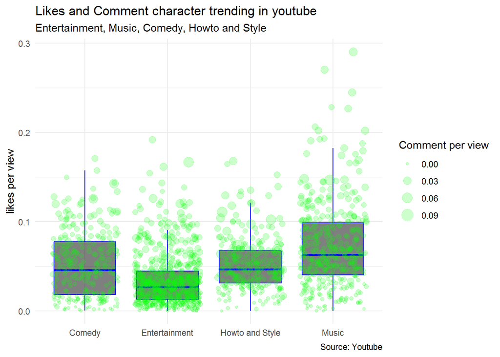

```r
 ggplot(data = Videos_top_4 , mapping = aes(x = category_id , y = likesp )) +
geom_boxplot(outlier.shape = NA, fill = "black" , col = "blue", alpha = 0.5 ) +
geom_jitter( (aes(size=commentp)) , col="green",
alpha = 0.2) +
  labs(title = "Likes and Comment character trending in youtube",
subtitle = "Entertainment, Music, Comedy, Howto and Style" ,
x =NULL ,
y = "likes per view" ,
size = "Comment per view",
caption = "Source: Youtube" ) +
theme_minimal()
```

## **3.2. More than equal to 10 Channel**

We are also planning to collaborate with a YouTube channel that often appears in trending video searches!  
We will look for YouTube channels that have **more than equal to 10 trending videos**. So that it can be determined which YouTube channel is good to be a collaboration partner.

Count the video frequency of each channel

```r
Videos_10chan <- as.data.frame(table(Videos_new$channel_title))
colnames(Videos_10chan) <- c("Title", "Freq")
```

Perform filtering for channels that have a frequency >= 10.

```r
Videos_10chan <- Videos_10chan[Videos_10chan$Freq >= 10 , ]
head(Videos_10chan, 10)
```

|  | Title | Freq |
| --- | --- | --- |
| 94 | BBC News | 13 |
| 172 | BuzzFeedVideo | 10 |
| 253 | CNN | 17 |
| 262 | CollegeHumor | 15 |
| 263 | ColliderVideos | 13 |
| 359 | E! Entertainment | 13 |
| 390 | ESPN | 24 |
| 415 | First We Feast | 17 |
| 481 | Great Big Story | 12 |
| 488 | Guardian News | 11 |

Sort from highest to lowest frequency and grab top 10 data from `Videos_10chan`

```r
Videos_10chan <- head(Videos_10chan[order(Videos_10chan$Freq, decreasing=T), ], 10)
```

Visualization.

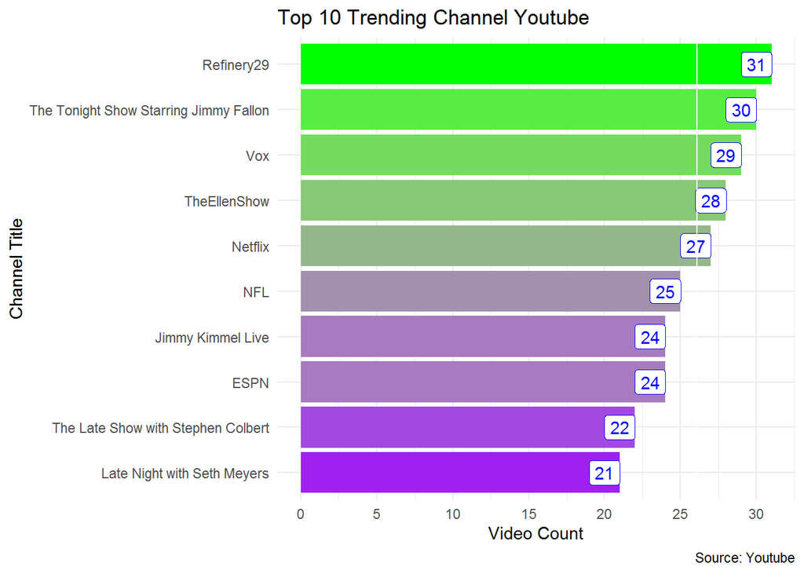

```r
ggplot(data = Videos_10chan[1:10,], mapping = aes(x=  Freq, y= reorder(Title,Freq))) +
  geom_col(aes(fill = Freq))  +
  labs(
    title = "Top 10 Trending Channel Youtube",
    x = "Video Count",
    y = "Channel Title",
    caption = "Source: Youtube"
  ) +
  scale_fill_gradient(low = "purple", high = "green") +   geom_label(mapping = aes(label = Freq),
            col = "blue",
            nudge_x = -1) +
  theme_minimal() +
  theme(legend.position = "none")+   geom_vline(xintercept=mean(Videos_10chan$Freq), col="white")+
  scale_x_continuous(breaks=seq(0,35,5))
```

## **3.3. Categories with Highest Trending Videos**

We will find out which category has the highest number of videos and want to know the proportion of each time period (Day/Night) when the video is published a lot.

```r
Videos_DayNight <- as.data.frame(table(Videos_new$category_id, Videos_new$publish_when))
head(Videos_DayNight)
```

|  | Var1 | Var2 | Freq |
| --- | --- | --- | --- |
| 1 | Autos and Vehicles | Day | 18 |
| 2 | Comedy | Day | 134 |
| 3 | Education | Day | 80 |
| 4 | Entertainment | Day | 399 |
| 5 | Film and Animation | Day | 77 |
| 6 | Gaming | Day | 10 |

Visualization.

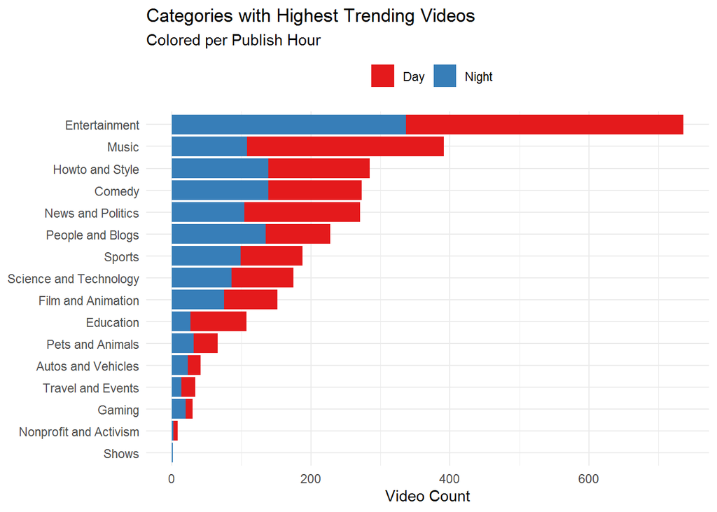

```r
ggplot(data = Videos_DayNight, mapping = aes(x = Freq, y = reorder(Var1, Freq))) +
  geom_col(mapping = aes(fill = Var2), position = "stack") +
  labs(x = "Video Count", y = NULL,
       fill = NULL,
       title = "Categories with Highest Trending Videos",
       subtitle = "Colored per Publish Hour") +
  scale_fill_brewer(palette = "Set1") +
  theme_minimal() +
  theme(legend.position = "top")
```

## **3.4. Publish Time & Views**

We will Visualize the trend of **average viewers** per `publish_hour` for the top 4 categories.

```r
Videos_TimeViews <- aggregate(views ~ category_id + publish_hour,
                       data = Videos_top_4,
                       FUN = mean)
```

Visualization.

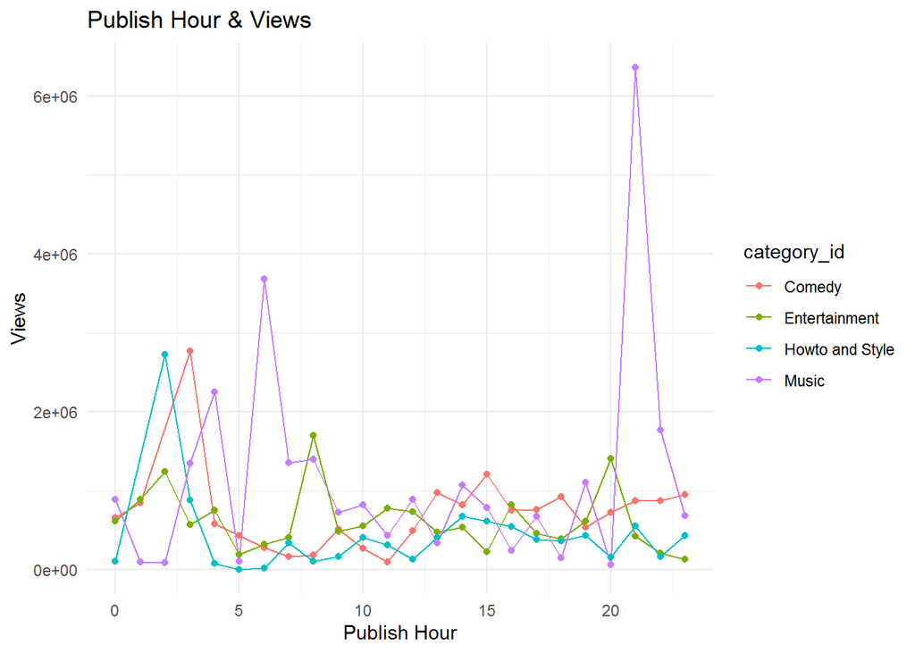

```r
ggplot(data = Videos_TimeViews, mapping = aes(x = publish_hour, y = views)) +
  geom_line(aes(group = category_id,
                col = category_id)) +
  labs(x = "Publish Hour", y = "Views",
       fill = NULL,
       title = "Publish Hour & Views") +
  geom_point(aes(col = category_id)) +
  theme_minimal()
```

# **4. DATA ANALYSIS**

**Conclusion** From the four analyzes above, the `Music` category is the most recommended category for new YouTubers as a channel category to be created. Likewise for active YouTubers, you can add a `Music` category to your YouTube channel to increase likes and views on the channel.